# Hands-On - AR(1) Stochastic Process: Stationary vs. Non-Stationary Process

### Comparing Average Values and Variances

Let's estimate the mean value and the variance for the stationary AR process

```matlab
av_valAR1 = mean(AR1)      % the average value for the stationary AR process
```

av_valAR1 = -0.2552

```matlab
varAR1 = varWG/(1-a_AR.^2) % the theoretical variance of the stationary process
```

varAR1 = 11.1111

```matlab
sampled_varAR1 = var(AR1)  % the sampled variance
```

sampled_varAR1 = 11.3466

Using the whole dataset, the mean and the varaince assume different values

```matlab
% check the average value using all the dataset
av_AR0 = mean(AR0)
```

av_AR0 = 0.6379

```matlab
% check the variance
sampled_varAR0 = var(AR0)  % the sampled variance
```

sampled_varAR0 = 453.2263

Run more than once, varying the variance of the white noise feeding in.

### What About the Autocovariance Function?

```matlab
Ncorr1 =1024; % select the max value of tau in the estimation formula
```

Check if the maximum value for the lag τ is respecting the constraint $|\tau| \le N-1$, with N the amount of available data.

```matlab
errMSG = 'The max lag must be less or equal to (N-1), with N the amount of available data!'; % error message
assert((Ncorr1 <= (Ndata-1)), errMSG)
```

Let evaluate the estimate, using the MATLAB command xcorr().

```matlab
[gamma_v1, lags_v1] = xcorr(AR1, Ncorr1,'unbiased');
% unbiased estimation of the autocovariance function

[gamma_v0, lags_v0] = xcov(AR0, Ncorr1,'unbiased');
% unbiased estimation of the autocorr. function of tilde_v

gammaAR1 = varAR1*(a_AR.^(abs(lags_v1))); % the true autocorrelation function of the stationary AR process
```

Now let's plot

- the acquired samples of the AR(1) process
- the samples of the estimated autocovaraiance and autocorrelation function toghethere with the corresponding values of the theoretical expression of the autocovariance function

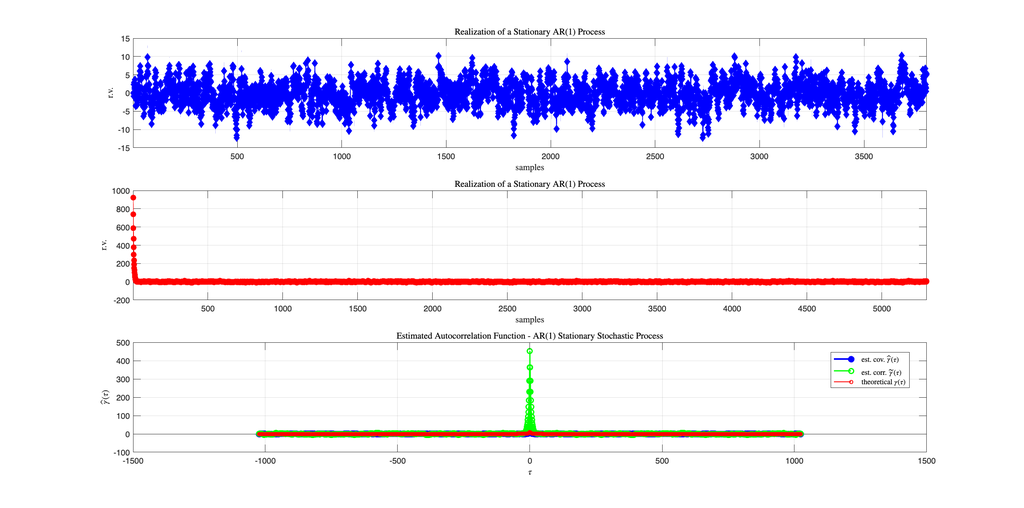

```matlab
figure('Units','normalized','Position',[0.1, 0.1, 0.85, 0.75]);

subplot(3,1,1);
plot(AR1,'db-','MarkerSize',6, 'MarkerFaceColor','b','LineWidth',1.0);grid on;
title('Realization of a Stationary AR$(1)$ Process', 'Interpreter','latex');
xlabel('samples', 'Interpreter','latex');ylabel('r.v.', 'Interpreter','latex');
xlim([1, Ndata]); % setting the extremum values on the x-axis[']]]=

subplot(3,1,2);

plot(AR0,'or-','MarkerSize',6, 'MarkerFaceColor','r','LineWidth',1.0);grid on;
title('Realization of a Stationary AR$(1)$ Process', 'Interpreter','latex');
xlabel('samples', 'Interpreter','latex');ylabel('r.v.', 'Interpreter','latex');
xlim([1, Ntot]); % setting the extremum values on the x-axis[']]]=

subplot(3,1,3);
% the covariance function of v(t)
stem(lags_v1, gamma_v1,'b','filled', 'LineWidth',2);
grid on; hold on;

% the correlation function of tilde_v
stem(lags_v0, gamma_v0,'g', 'LineWidth',1.5);

% the theoretical expression of the covaraince function
stem(lags_v1, gammaAR1, 'r', 'MarkerSize',4,'LineWidth',1.0);
xlabel('$\tau$', 'Interpreter','latex');ylabel('$\hat{\gamma}(\tau)$',...
    'Interpreter','latex');
title('Estimated Autocorrelation Function - AR$(1)$ Stationary Stochastic Process',...
    'Interpreter','latex');
legend('est. cov. $\hat{\gamma}(\tau)$', 'est. corr. $\tilde{\gamma}(\tau)$','theoretical $\gamma(\tau)$', 'Location', 'best', 'Interpreter', 'latex')
```